# 1 Experimento - Passeio Aleatória

[figure not shown]

Figure 1.1: O andar de um bebado é usado como alegoria para representar a ideia de uma caminhada aleatoria.

## 1.1 Objetivo

Introduzir os visitantes da mostra a idéia de caminhada aleatória e estimular o pensamento probabilistico dos mesmos.

## 1.2 Descrição

Suponha que o movimento de um certo ponto no plano pode ser descrito da seguinte maneira.

Uma moeda honesta é lançada, caso dê cara o ponto avança em diagonal para a direita, caso dê coroa ela avança em diagonal para a esquerda, onde cada lançamento pode ser considerado um “passo”.

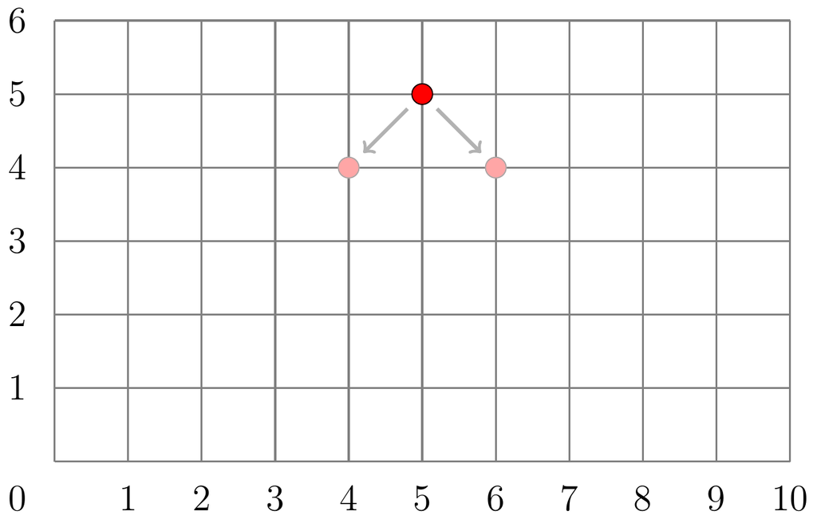

Sabendo disso qual será a posição final desse ponto após 4 passos ?

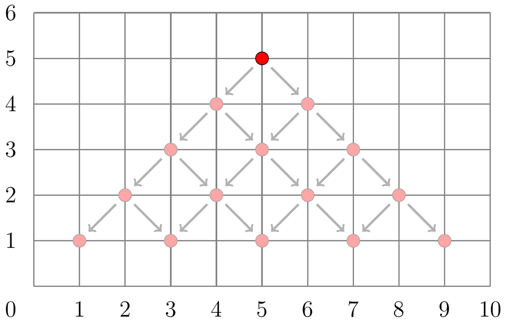

## 1.3 Construção

Para esse experimento são necessarios:

1. Um “marcador de posição”, item qualquer que possa ser utilizado para marcar a posição atual.
2. O desenho de uma malha quadriculada ou para ser mais intuitivo somente o desenho dos caminhos possiveis.
3. Uma moeda honesta.

## 1.4 Execução

Uma sugestão de passo a passo é:

1. Perguntar ao participante em qual das possiveis posições finais o marcador irá terminar.
2. Em seguida posicionar o marcador na origem e lançar a moeda.
3. Dependendo do resultado o marcado será movido para uma das proximas possições.
4. Assim sucessivamente até a moeda ter sido lançada quatro vezes.
5. Ao final é explicada a ideia por traz do experimento e a teoria, por exemplo o porque da moeda acabar mais nas posições centrais do que nas bordas.

## 1.5 Teoria

### 1.5.1 Probabilidades e distribuição binomial

Como a moeda é honesta temos que os possíveis movimentos com mesmo número de passos são equiprováveis, logo o que vai determinar a probabilidade do ponto terminar em certa posição final vai ser as dado pelas diferentes formas que ele tem para chegar lá vezes $1/2^n$ onde $n$ é o número de passos.

O número de formas que o ponto pode chegar na k-ésima posição final, $0 \leq k \leq n$, após n passos é dada pelo coeficiente binomial $n \choose k$.

Logo a probabilidade de apos n passos o ponto termine na posição k é dada por

$$P(k,n) = {n \choose k} \frac{1}{2^n} \ , \ 0 \leq k \leq n$$

Que é o formato de uma distribuição binomial com parâmetros $(n, p = 1/2)$, logo podemos concluir que com um n grande a distribuição de probabilidades das posições finais se assemelham com uma distribuição normal centrada no valor n/2.

Logo o ponto possui maior probabilidade de visitar as posições centrais do que visitar as posições nos extremos.

## 1.6 Referências e leituras complementares

**Weisstein, Eric W**. “Random Walk–1-Dimensional.”, disponível em: https://mathworld.wolfram.com/RandomWalk1-Dimensional.html

**Michael Fowler**. “The One-Dimensional Random Walk”, disponível em: https://galileo.phys.virginia.edu/classes/152.mf1i.spring02/RandomWalk.htm